# Data Science for Public Policy Final Project

Examining the Relationship Between Economic Access and Status and Public Health Outcomes in the D.C. Area Part 02

Author

Adriana Vance, Kyle Kim, Elena Koshkin, Kamiryn Rose

[Loading necessary packages]

```r
library(httr)
library(jsonlite)
library(tidyverse)
library(tidycensus)
library(purrr)
library(sf)
library(dplyr)
library(patchwork)
library(recipes)
library(ggplot2)
library(tidyclust)
library(tigris)
library(broom)
library(factoextra)
library(tmap)
library(mapproj)
library(leaflet)
library(randomForest)
library(caret)
library(tidymodels)
library(hexbin)
library(scales)
library(gganimate)
library(gifski)
library(fpc)
```

```r
# datasets from first half of final project

#pulling Tigris package tracts data
#suppress progress bars?

options(tigris_use_progress_bars = FALSE)

Maryland_tracts <- tracts(
state = "MD",
county = c("Montgomery", "Prince George's"),
cb = FALSE,
resolution = "500k",
year = 2010)
Virginia_tracts <- tracts(
  state = "VA",
  county = "Fairfax County",
  resolution = "500k",
  year = 2010
)
DC_tracts <- tracts(
  state = "DC",
  resolution = "500k",
  year = 2010
)
DMV_tracts <- rbind_tigris(DC_tracts, Virginia_tracts, Maryland_tracts)

#Read in CSV of CDC data
Health <- read_csv("PLACES.csv")

# Look at types of health outcome measures
Measures <- Health %>%
  group_by(Measure) %>%
  summarize(n = n())

MeasureIDs <- Health %>%
  group_by(MeasureId) %>%
  summarize(n = n())

# We want to look for current rates of asthma, heart disease, diabetes, stroke, and depression
Health <- Health %>%
  filter(
    MeasureId == "CASTHMA" |
      MeasureId == "CHD" |
      MeasureId == "DIABETES" |
      MeasureId == "STROKE" |
      MeasureId == "DEPRESSION")

debt_to_income <- read.table("debt_to_income.txt", header = FALSE)
# Have to manually name columns

colnames(debt_to_income) <- c('enterprise', 'record_num','state_postal_code', 'MSA', 'COUNTYFP', 'NAME10', 'percent_minority', 'median_income', 'MSA_median_income', 'tract_income_ratio', 'borrower_income','AMI', 'borrower_income_ratio', 'UPB','purpose_of_loan', 'fed_guarantee', 'num_borrowers', 'first_time_borrower', 'borrower_race_1', 'race_2', 'race_3', 'race_4', 'race_5', 'borrower_ethnicity', 'co_borrower_race_1', 'co_race_2', 'co_race_3', 'co_race_4', 'co_race_5',   'co_borrower_ethnicity', 'borrower_gender', 'co_borrower_gender', 'borrower_age', 'co_borrower_age', 'occupancy_code', 'rate_spread', 'HOEPA_status', 'property_type', 'lien_status', 'borrower_over_sixtytwo', 'co_borrower_over_sixtytwo', 'LTV_ratio', 'note_date', 'mortgage_term', 'num_units', 'interest_rate', 'note_amount', 'preapproval', 'application_channel', 'AUS_name', 'borrower_credscore_model', 'co_borrower_credscore_model', 'DTI_ratio', 'discount_points', 'rate_period', 'manufactured_home_ownership', 'property_value', 'rural_tract', 'lower_MS_delta', 'Mid_Appalachia', 'persistent_poverty_county', 'concentrated_poverty', 'high_opportunity_area', 'QOZ')

counties <- c(1, 59, 31, 33) # Name county vector to filter dataset to needed counties only

debt_to_income <- debt_to_income %>%
  filter(MSA == 47900)

debt_to_income <- debt_to_income %>%
  filter(COUNTYFP == counties) # Filtering to needed counties

# Mutate dataset to match county names of TIGRIS shapefile
debt_to_income <- debt_to_income %>%
  mutate(COUNTYFP =
    if_else(COUNTYFP == 1, "001", as.character(COUNTYFP)))

debt_to_income <- debt_to_income %>%
  mutate(COUNTYFP =
           if_else(COUNTYFP == 59, "059", as.character(COUNTYFP)))

debt_to_income <- debt_to_income %>%
  mutate(COUNTYFP =
           if_else(COUNTYFP == 31, "031", as.character(COUNTYFP)))

debt_to_income <- debt_to_income %>%
  mutate(COUNTYFP =
           if_else(COUNTYFP == 33, "033", as.character(COUNTYFP)))

debt_to_income$NAME10 <- as.numeric(debt_to_income$NAME10)

DMV_tracts$NAME10 <- as.numeric(DMV_tracts$NAME10)

debt_to_income$NAME10 <- debt_to_income$NAME10 / 100

#Merging the datasets by census tract name
debt_tract_2 <- full_join(DMV_tracts, debt_to_income, by = "NAME10")

# Setting CRS for geospatial visualizations

debt_tract_2 <- debt_tract_2 %>%
  st_as_sf(coords = c("INTPTLON10", "INTPTLAT10"), remove = FALSE) %>%
  st_set_crs(value = 4326) # setting CRS


debt_tract_2 <- st_transform(debt_tract_2, crs = 4326)

#Merging health dataset with debt_tract_2

#Converting long and lat coordinates to sf objects
debt_tract_2_sf <- st_as_sf(debt_tract_2, coords = c("INTPTLON10", "INTPTLAT10"), crs = 4326)

# Convert 'Geolocation' column to an sf object
Health_sf <- st_as_sf(Health, wkt = "Geolocation", crs = 4326)

#suppress progress bar
options(sf_progress = FALSE)

#Transform debt dataset to match health
debt_tract_2_sf <- st_transform(debt_tract_2_sf, st_crs(Health_sf))

#Spatial Join
health_debt <- st_join(debt_tract_2_sf, Health_sf, join = st_intersects)
```

## Part 04

#### Machine Learning Model

```r
set.seed(102102938)

split <- initial_split(data = debt_to_income, prop = 0.75)

debt_train <- training(x = split)
debt_test <- testing(x = split)

## Health outcome for machine learning model will be percentage of instances of depression in a census tract
```

### Machine Learning Model #1: Predicting the percentage of minorities in a census tract using the single-family loan data

```r
debt_rec <- recipe(percent_minority ~ borrower_income + borrower_age + borrower_income_ratio + tract_income_ratio + DTI_ratio + interest_rate + note_amount, data = debt_train) %>%
  step_normalize(all_numeric_predictors()) %>%
  step_corr(all_numeric_predictors())

# Creating tuning grid for lasso model
lasso_grid <- grid_regular(penalty())

# LASSO model
lasso_mod <- linear_reg(penalty = tune(), mixture = 1) %>%
  set_engine("glmnet")

# LASSO workflow
lasso_wf <- workflow() %>%
  add_recipe(debt_rec) %>%
  add_model(lasso_mod)

folds <- vfold_cv(data = debt_train, v = 10, repeats = 1)

# LASSO fit
lasso_fit <- lasso_wf %>%
  tune_grid(
    resamples = folds,
    grid = lasso_grid,
    metrics = metric_set(rmse, mae),
    control = control_grid(save_pred = TRUE))

# Evaluating models
lasso_metrics <- lasso_fit %>%
  collect_metrics(summarize = TRUE)

lasso_fit %>%
  select_best(metric = "rmse")
```

```
# A tibble: 1 × 2
       penalty .config
         <dbl> <chr>
1 0.0000000001 Preprocessor1_Model1
```

```r
# The RMSE of this model's best fit is around 22.
```

[output not shown]

Taking the results from this prediction using our debt dataset, we decided to try a different type of model. LASSO regression is best for linear relationships, and it makes sense that this model may not capture all of the variation in the percentage of minorities across all census tracts in the DMV.

For our next machine learning model, we will take what we’ve learned from the performance of this model to predict something a bit more complex: health outcomes across the DMV using economic data.

### Machine Learning Model #2: Predicting rates of depression in a census tract using economic predictors from the debt-to-income dataset

We’ve chosen a random forest model to model the relationship between economic factors and depression because random forest models adapt easily to many predictors, and nonlinear relationships. Below, we test two different random forest models and refine one with hyperparameter tuning to get a model with refined predictions of rates of depression in a census tract.

```r
# Filtering dataset for second machine learning  model

# We want only observations for rates of depression, and to exclude columns that have all values as NA or that are not interpretable by random forest modeling
depression_debt <- health_debt %>%
  drop_na(Data_Value) %>%
  filter(MeasureId == "DEPRESSION") %>%
  select(-Data_Value_Footnote, -Data_Value_Footnote_Symbol) %>%
  st_drop_geometry()

# Omit all NA values from dataset
depression_debt <- na.omit(depression_debt)

set.seed(12122023)
split2 <- initial_split(data = depression_debt, prop = 0.8)

depression_train2 <- training(x = split2)
depression_test2 <- testing(x = split2)


# Train the initial randomForest model with specified predictors
rf_mod <- randomForest(Data_Value ~ borrower_income + borrower_age + borrower_income_ratio + tract_income_ratio + DTI_ratio + interest_rate + note_amount + property_value + percent_minority, data = depression_train2)

rf_mod
```

```
Call:
 randomForest(formula = Data_Value ~ borrower_income + borrower_age +      borrower_income_ratio + tract_income_ratio + DTI_ratio +      interest_rate + note_amount + property_value + percent_minority,      data = depression_train2)
               Type of random forest: regression
                     Number of trees: 500
No. of variables tried at each split: 3

          Mean of squared residuals: 1.634195
                    % Var explained: 77.66
```

This model only explains about 77.6% of the variance in the rates of depression in each census tract. We think this is because there is a lack of tuning the model, and because we limited the number of predictors such that there was not enough information.

Next, we will try a similar random forest model, but with more predictors and some hyperparameter tuning to find the best number of mtrys.

```
mtry = 32  OOB error = 0.001130305
Searching left ...
mtry = 16   OOB error = 0.002019131
-0.7863605 0.01
Searching right ...
mtry = 64   OOB error = 0.001732278
-0.5325765 0.01
```

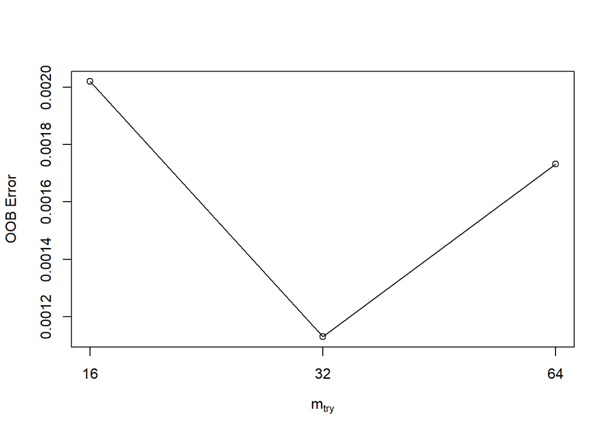

```r
# Trying some tuning to see if we can find the best amount of mtrys to use for the model
bestmtry <- tuneRF(depression_train2,depression_train2$Data_Value,stepFactor = 2, improve = 0.01, trace = TRUE, plot = T, doBest = TRUE)
```

```r
# tuneRF shows that the best amount of mtrys is 32. Running random forest model again with 32 mtrys to see if it further optimizes the model.
best_mtry <- 32

rf_mod3 <- randomForest(Data_Value ~., data = depression_train2, mtry = best_mtry)

rf_mod3
```

```
Call:
 randomForest(formula = Data_Value ~ ., data = depression_train2,      mtry = best_mtry)
               Type of random forest: regression
                     Number of trees: 500
No. of variables tried at each split: 32

          Mean of squared residuals: 0.0004910996
                    % Var explained: 99.99
```

We used hyperparameter tuning to find the best number of mtrys for the model, and plotted the result. After finding that the best number of mtrys was 32, we added this parameter to the model. As a result, this model shows great improvement from the previous, explaining 99.99% of the variance. We can use this model to predict health outcomes on the testing dataset.

```r
predicted_values <- predict(rf_mod3, newdata = depression_test2, type = "class")

test_predictions <- bind_cols(
  depression_test2, predicted_values)

test_predictions <- test_predictions %>%
  rename(.pred = ...99)

metrics(test_predictions, truth = Data_Value, estimate = .pred)
```

```
# A tibble: 3 × 3
  .metric .estimator .estimate
  <chr>   <chr>          <dbl>
1 rmse    standard      0.118
2 rsq     standard      0.999
3 mae     standard      0.0538
```

```r
prediction_table <- tibble(test_predictions$Data_Value, test_predictions$.pred)
```

The prediction table shows that we have successfully trained a model that predicts 99% of the variance in our variable of interest, which reflects the rates of depression in each census tract.

This model used predictors such as percent minority census tracts, debt to income ratio, median income of a census tract, and many other racial and economic factors in the data to be able to predict the depression rates in a census tract.

Using a machine learning model that adapts to non-linear relationships has shown us that there is indeed a relationship between economic/racial factors and public health outcomes, such as depression.

## Part 05

## Cluster Analysis

```r
# filtering the data to use for the cluster analyis
dti_data <- debt_to_income %>%
  select(percent_minority, DTI_ratio)

# creating the recipe
dti_pca_rec <- recipe(~ ., data = dti_data) %>%
  step_pca(all_numeric(), id = "pca") %>%
  prep(data = dti_data) %>%
  bake(new_data = dti_data)


#create the function
debt_pca_fun <- function(DTI, df){
  debt_pca <- df %>%
    replace(is.na(.), 0) %>%
    filter(DTI_ratio == DTI)

debt_pca_rec <- recipe(~ ., data = dti_data) %>%
    step_pca(all_numeric(), num_comp = 2) %>%
    step_normalize(all_predictors()) %>%
    prep(data = dti_data) %>%
    bake(new_data = dti_data) %>%
    select(PC1, PC2)


kmeans_rec <- recipe(~ ., data = dti_data) %>%
  step_select(all_numeric())

  debt_pca_spec <- k_means(
  num_clusters = 4
) %>%
  set_engine("stats", nstart = 100)

debt_pca_workflow <- workflow(
  preprocessor = kmeans_rec,
  spec = debt_pca_spec
)

final_fit <- debt_pca_workflow %>%
  fit(data = dti_data)

debt_clusters <-
  bind_cols(dti_data, debt_pca_rec, cluster = final_fit %>%
    extract_cluster_assignment() %>%
    pull(.cluster) )

return(debt_clusters)
}

#mapping the output
DTI<- 20:50
set.seed(20220413)
final_result <- map_dfr(.x = DTI, .f = debt_pca_fun, df = debt_to_income)

glimpse(final_result)
```

```
Rows: 513,143
Columns: 5
$ percent_minority <dbl> 57.00, 99.59, 94.92, 98.69, 93.44, 44.99, 76.98, 78.4…
$ DTI_ratio        <int> 20, 30, 10, 30, 40, 36, 37, 47, 30, 42, 20, 10, 20, 3…
$ PC1              <dbl> 0.1194779, -1.6822615, -1.1329552, -1.6481197, -1.635…
$ PC2              <dbl> -0.68362682, -1.36493838, -2.47283218, -1.33732112, -…
$ cluster          <fct> Cluster_1, Cluster_2, Cluster_2, Cluster_2, Cluster_2…
```

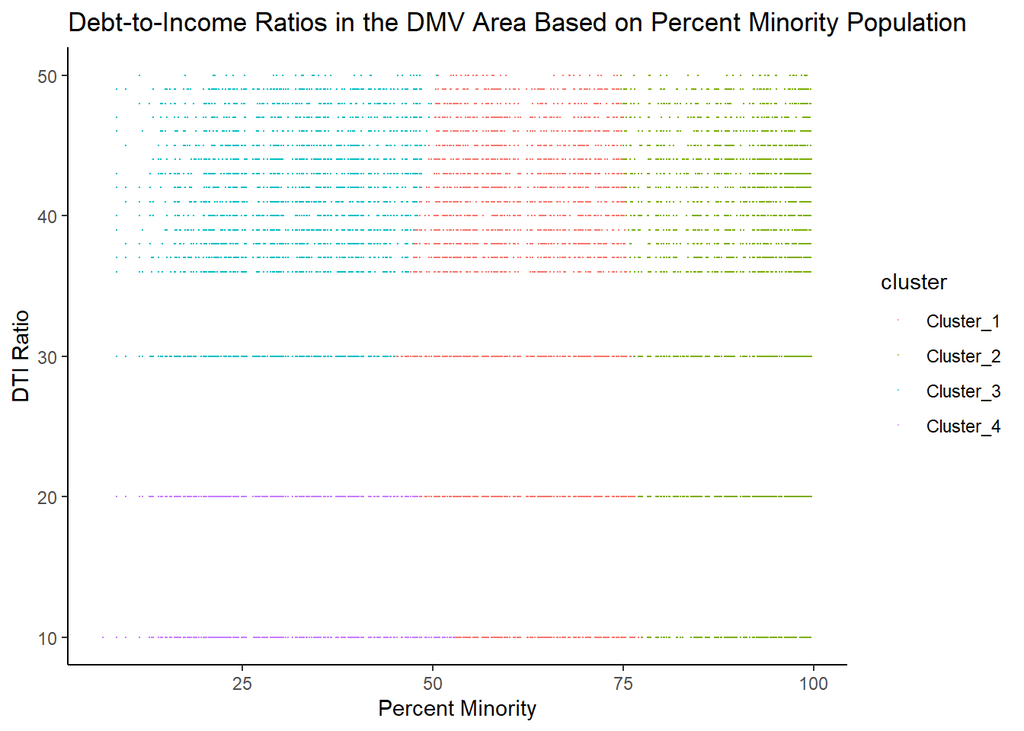

```r
# mapping the cluster plot
clust_plot <- final_result %>%
  ggplot() +
  geom_point(
    mapping = aes(x = percent_minority, y = DTI_ratio, color = cluster),
    alpha = 0.5, size = 0.1
  ) +
  labs(
    title = "Debt-to-Income Ratios in the DMV Area Based on Percent Minority Population",
    x = "Percent Minority",
    y = "DTI Ratio"
  ) +
  theme_classic()

clust_plot
```

This plot shows the variance explained by our principal component analysis clusters. We can see here that the variance increases in our clusters as the debt to income ratio increases. Three of our clusters show uniformity in structure across the plot, however Cluster 4 is condensed around a low debt to income ratio and a low percentage of minorities living in a census tract. DTI ratio increases variance, while percent minority decreases variance. These results indicate that perhaps the variation in debt to income ratios is not well explained by the racial demographics of a census tract. This is a bit contradictory to our hypothesis, but this could also be an indicator that there are other economic outcomes that correlate with debt to income ratios better. The visual nature of the plot suggests that perhaps kmeans clustering is not the best method for analyzing our data. Perhaps, if we had used a different predictor or clustered our data based on health conditions, we would have found a better relationship between our variables.

```r
# PCA variance check

#filter dataframe to DTI ratios 20 and over

#concatenate two columns to make matching columns with Health dataset
debt_to_income$CountyFIPS <- paste0(debt_to_income$state_postal_code, debt_to_income$COUNTYFP)

#filter out health dataset to append to DTI data
Health_append <- Health %>%
  select(CountyFIPS, MeasureId, Data_Value, TotalPopulation)

DTI_clust <- debt_to_income %>%
  select(DTI_ratio, NAME10, CountyFIPS, percent_minority, concentrated_poverty)

#make recipe
DTI_clust_rec <- recipe(~., DTI_clust) %>%
  step_pca(all_numeric_predictors(), id = "pca_") %>%
  step_normalize(all_numeric_predictors()) %>%
  prep()

#variance
tidy(DTI_clust_rec, number = 1, type = "variance")
```

```
# A tibble: 16 × 4
   terms                         value component id
   <chr>                         <dbl>     <int> <chr>
 1 variance                    3.48e+7         1 pca_
 2 variance                    1.19e+3         2 pca_
 3 variance                    1.92e+2         3 pca_
 4 variance                    6.44e-2         4 pca_
 5 cumulative variance         3.48e+7         1 pca_
 6 cumulative variance         3.48e+7         2 pca_
 7 cumulative variance         3.48e+7         3 pca_
 8 cumulative variance         3.48e+7         4 pca_
 9 percent variance            1.00e+2         1 pca_
10 percent variance            3.41e-3         2 pca_
11 percent variance            5.50e-4         3 pca_
12 percent variance            1.85e-7         4 pca_
13 cumulative percent variance 1.00e+2         1 pca_
14 cumulative percent variance 1.00e+2         2 pca_
15 cumulative percent variance 1.00e+2         3 pca_
16 cumulative percent variance 1   e+2         4 pca_
```

```r
#bake to get principal components
DTI_pcs <- DTI_clust_rec %>%
  bake(new_data = NULL)

#merge dataframes
DTI_Health_clust <- merge(DTI_pcs, Health_append, by = "CountyFIPS")

glimpse(DTI_Health_clust)
```

```
Rows: 18,584,035
Columns: 8
$ CountyFIPS      <fct> 11001, 11001, 11001, 11001, 11001, 11001, 11001, 11001…
$ PC1             <dbl> 2.041144, 2.041144, 2.041144, 2.041144, 2.041144, 2.04…
$ PC2             <dbl> 2.613634, 2.613634, 2.613634, 2.613634, 2.613634, 2.61…
$ PC3             <dbl> 1.023911, 1.023911, 1.023911, 1.023911, 1.023911, 1.02…
$ PC4             <dbl> 1.624095, 1.624095, 1.624095, 1.624095, 1.624095, 1.62…
$ MeasureId       <chr> "DEPRESSION", "CASTHMA", "STROKE", "CHD", "STROKE", "S…
$ Data_Value      <dbl> 16.8, 11.9, 2.3, 3.2, 1.4, 3.9, 12.4, 17.5, 1.2, 1.9, …
$ TotalPopulation <dbl> 1969, 3670, 1455, 4913, 2910, 2507, 2911, 1962, 6233, …
```

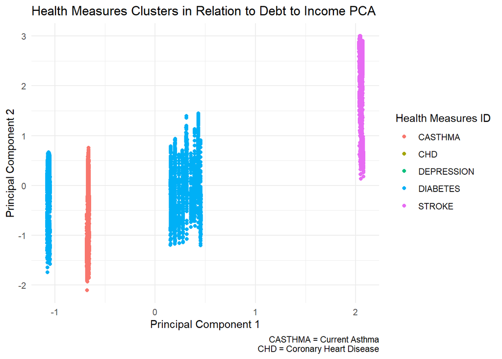

```r
#scatter plot
p5 <- ggplot(DTI_Health_clust, aes(x = PC1, y = PC2, color = MeasureId)) +
  geom_point() +
  labs(
    title = "Health Measures Clusters in Relation to Debt to Income PCA",
    x = "Principal Component 1",
    y = "Principal Component 2",
    caption = "CASTHMA = Current Asthma\nCHD = Coronary Heart Disease",
    color = "Health Measures ID") +
theme_minimal()

p5
```

This scatterplot attempts to show health measures clustered together based upon the PCA variance of Debt-to-income variables. This plot shows that stroke has the highest variance in relation to select debt to income variables. It also shows that diabetes and asthma make up some of that variance, although not as much. Moreover, after merging parts of the health measures data with the debt to income data, the clustering graphics are unclear in their representations suggesting that the cluster analysis that we fitted to these indicators may not be optimal for this data compared to our machine learning models and geospatial visualizations which did a much better job at presenting and predicting the relationship between these measures.

#### Data Interpretation and Analysis

Our research aimed to document and analyze the relationships between health outcomes, economic conditions, geography, and demographics across various census tracts in the DMV area. Through this exploration, we found several patterns suggesting correlative relationships that could be invaluable when guiding policy decisions and healthcare initiatives.

## Discussion of Results

### Interpreting the findings:

#### Health Outcomes and Geographic Correlation:

As we observed the mapping of health outcomes across census tracts in the DMV area, we found health issues were pervasive regardless of ward. This finding suggests a widespread impact of these health conditions, irrespective of any geographic distinctions. However, the absence of a clear pattern linking health outcomes to specific areas underscores the complexity of health determinants and indicates that factors beyond geography play a significant role. This lack of clear linkage could lead us to discover that other factors, like economic status, may have a more influential effect on health.

#### Housing Loan Dynamics:

We were interested in finding out the number of borrowers by loan type in order to provide some insight into borrowing behaviors and financial priorities within the population. In our observation, there was a significant skew towards refinancing loans rather than new home purchases. This disparity could reflect broader economic trends, such as market stability or homeowner equity growth. These results may be indicative of the low housing stock and high average value in the DMV area, thus explaining why homeowners are not selling, not buying, but mostly refinancing and remaining stagnant.

There is also a notable disparity in loan amounts across minority-dominated tracts. There is also a significant concentration of single-family home loans in the near-100% minority census tracts, yet we found that the loans trend much lower for minority census tracts, around 100,000 USD, as opposed to mostly white neighborhoods trending closer to 300,000 USD. This discovery hints at underlying economic inequalities and raises questions about accessibility to financial services and its implications on housing stability in minority communities. It is possible that, due to several systemic and economic reasons, minority communities have less access to higher loans due to either a lower net worth or higher debt-income ratio, allowing them less leverage and, therefore, less valuable loans. It is also important to consider the process banks use to evaluate the financial status of potential borrowers and determine if there is a bias or unjust practices that could be putting minorities at a disadvantage, even against white individuals of the same economic status and credit risk.

### Bank Distribution and Economic Implications in DC:

Through our analysis, we observed that there is a very high concentration of banks in Ward 2 with a notable lack in Wards 7, 8, and 4. This finding seems to align with economic disparities in these areas and could contribute to the cycle of poverty as areas get poorer, resources to build financial stability dissipate, and the cycle continues. This pattern indicates that access to banking is a key economic resource yet is very unevenly distributed, potentially exacerbating economic inequalities.

### Debt-to-Income (DTI) Ratio Insights:

The diverse DTI ratios across tracts and their potential link to health conditions suggest a complex interplay between financial burden and health. This aspect of our research opens avenues for exploring how economic stressors impact public health. Within 1 mile of a bank, census tract 44.00 had the highest number of people with a debt-to-income ratio over 20, with about 24,684 people. Census tracts 53.01, 52.01, and 55.00 had the next highest numbers. Census tract 44.00 is the area near Howard University, on U Street. Census tract 53.01 is near Dupont Circle. Census tract 55.00 is the area near Foggy Bottom and GWU, while Census tract 52.01 is in Logan Circle. These census tracts are all densely populated, relatively high-income, and close to the city center as well as universities and restaurants. Those living here are very likely to be students or wealthier young professionals with a greater ability and liberty to handle paying pay larger loans, or even have assistance in that regard from family. The fact that there are high concentrations of people with high debt-to-income ratios in these areas that are all within 1 mile of a bank affirms what we found in the previous map with proximity to banks set at a quarter of a mile. Single-family homes are quite expensive and difficult to obtain in these areas, but there is also a wide variety of resources available in these areas. These census tracts are all also majority non-minority, which coincides with literature that points to majority Black neighborhoods having low access to banking and low access to housing loans.

### Geospatial Analysis:

Our geospatial analysis aimed to examine whether there is a correlation between the proximity of banks and the incidence of coronary heart disease (CHD) in various areas. Our expectation was that areas with better access to financial institutions would correlate with lower instances of CHD and better health outcomes overall, under the assumption that economic prosperity, facilitated by bank access, would lead to better health outcomes. However, the analysis revealed an unexpected pattern: areas with a higher concentration of banks also showed a higher number of CHD cases. This contradicts our initial hypothesis and suggests that the presence of banks, as a proxy for economic health, does not directly translate to better physical health outcomes. It raises questions about the directness and nature of the relationship between economic factors and health conditions. Health outcomes, particularly chronic conditions like CHD, are influenced by a multitude of variables including lifestyle choices, environmental factors, genetic predispositions, and more-so it is important to note that the lack of significant results does not invalidate the hypothesis; it merely highlights the complexity of the factors at play. One possible explanation is that this may be because in tracts where a majority of people are unable to leverage more debt against their income (for example, to emergency medical care), they are worse off in terms of their health.

### Machine Learning Analysis:

We chose a random forest model to model the relationship between economic factors and depression. This is because random forest models adapt easily to many predictors and nonlinear relationships. We wanted to test two different random forest models and refine one with hyperparameter tuning in order to output a model with refined predictions of rates of depression in a census tract. We found that this model only explains about 77.6% of the variance in the rates of depression in each census tract. We hypothesize that this is due to a lack of tuning the model as well as our limiting of the number of predictors in such a way that not enough information remained to come to a more accurate conclusion. We will tried a random forest model with all predictors using hyperparameter tuning to find the best number of mtrys for the model, and plotted the result. We found that the best number of mtrys was 32, and we added this parameter to the model. As a result, our model shows great improvement from the previous, explaining 99.99% of the variance. We can now use this model to predict health outcomes on the testing dataset. Using a machine learning model that adapts to non-linear relationships has shown us that there is indeed a relationship between economic/racial factors and public health outcomes, such as depression. This success underscores the significant role of economic conditions in public health. The model’s improvement post-tuning highlights the importance of robust analytical approaches in understanding such complex relationships.

### Limitations and Areas for Future Research:

The lack of a clear geographic pattern in health outcomes suggests that our analysis could benefit from incorporating additional variables such as environmental factors or access to healthcare in a future model. The interpretation of loan data is, unfortunately, limited by the absence of deeper contextual information, such as the reasons behind refinancing trends or the impact of local housing policies. The relationship between bank distribution and economic outcomes, while suggestive, requires further investigation to establish causality. The DTI analysis could be improved with more granular data, for example, individual credit histories, or long-term financial trends. Our machine learning models, while effective, may not fully capture the multifaceted nature of the relationship between economics and health. Future models could integrate more diverse datasets and employ more complex algorithms to better understand the irregular, non-linear relationship. The earlier finding that areas with more banks have higher CHD instances was the result of various confounding factors. For example, these areas might also be more urbanized, with lifestyle factors that contribute to CHD, such as higher stress levels, more sedentary jobs, or greater availability of unhealthy food options. To further understand the relationship between bank proximity and health outcomes, it may be beneficial to control for variables like these or conduct a multivariate analysis that includes additional economic indicators, such as employment rates, income levels, or access to healthcare services. Furthermore, it might be worth exploring other methods of analysis or different health outcomes that could be more directly related to economic conditions. For instance, mental health issues like stress and anxiety could have a stronger correlation with economic factors than CHD does, though these were not possible given our dataset. The effect of time is another factor we found challenging to address. Our analysis is cross-sectional and provides a snapshot in time rather than capturing trends over time is less than ideal. Observing how time affects these changes is critical for understanding the dynamics between economic conditions and health outcomes.

Ultimately while our analysis produced surprising results, it also provides valuable insights into the complexities of health determinants and opens up new avenues for research. It is a reminder that socioeconomic factors and health outcomes are part of a complex intertwined web that requires nuanced, multifaceted, extremely technical approaches to fully understand and design an effective policy.